# HW 8

Shijia Gao

5/18/2019

```r
library(vars)
library(magrittr)
library(tidyquant)
library(timetk)
library(egg)
library(stargazer)
```

```r
library(grid)
library(gridExtra)
library(plotly)
library(urca)
library(ggplot2)
library(scales)
library(ggfortify)

theme_set(theme_bw() +
          theme(strip.text.x = element_text(hjust = 0),
                strip.text.y = element_text(hjust = 1),
                strip.background = element_blank()))
```

## Problem 1

Obtain monthly time series for Crude Oil Prices: West Texas Intermediate (WTI), MCOILWTICO, and the monthly time series for US Regular Conventional Gas Price, GASREGCOVM.

1. Create a single time series plot with two log prices log pGAS and log pOIL for the sample 1995M1-2017M4.

```r
energy_tbl1 <-
    tq_get(c("MCOILWTICO"),
           get = "economic.data", from = "1995-01-01", to = "2017-12-31") %>%
          rename(poil=price) %>%
    mutate(yearmon = as.yearmon(date),
           logpoil=log(poil),
           dloil= log(poil)-lag(log(poil))) %>%
    ungroup() %>%
    select(date, yearmon, logpoil, dloil)

energy_tbl2 <-
    tq_get(c("GASREGCOVM"),
           get = "economic.data", from = "1995-01-01", to = "2017-12-31") %>%
    rename(pgas=price) %>%
    mutate(yearmon = as.yearmon(date),
           logpgas=log(pgas),
            dlgas= log(pgas)-lag(log(pgas))) %>%
    ungroup() %>%
    select(date, yearmon, logpgas, dlgas)

energy_tbl <- inner_join(energy_tbl1  ,energy_tbl2 ,by = "yearmon")
energy_tbl
```

```
## # A tibble: 276 x 7
##    date.x     yearmon       logpoil     dloil date.y     logpgas      dlgas
##    <date>     <S3: yearmon>   <dbl>     <dbl> <date>       <dbl>      <dbl>
##  1 1995-01-01 1月 1995         2.89  NA       1995-01-01  0.0639  NA
##  2 1995-02-01 2月 1995         2.92   0.0290  1995-02-01  0.0564  -0.00753
##  3 1995-03-01 3月 1995         2.92  -0.00162 1995-03-01  0.0573   0.000945
##  4 1995-04-01 4月 1995         2.99   0.0708  1995-04-01  0.0989   0.0416
##  5 1995-05-01 5月 1995         2.98  -0.00807 1995-05-01  0.159    0.0598
##  6 1995-06-01 6月 1995         2.92  -0.0676  1995-06-01  0.171    0.0119
##  7 1995-07-01 7月 1995         2.85  -0.0626  1995-07-01  0.138   -0.0326
##  8 1995-08-01 8月 1995         2.89   0.0390  1995-08-01  0.113   -0.0247
##  9 1995-09-01 9月 1995         2.90   0.0116  1995-09-01  0.103   -0.0108
## 10 1995-10-01 10月 1995        2.86  -0.0449  1995-10-01  0.0788  -0.0237
## # ... with 266 more rows
```

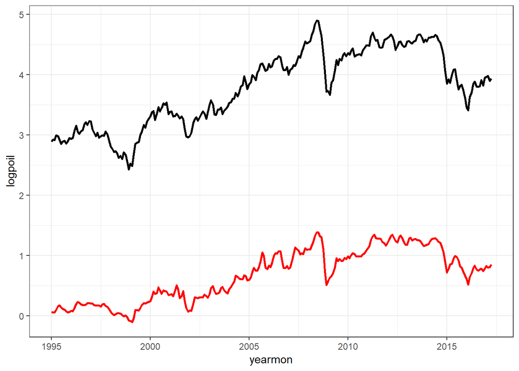

```r
ss <- subset(energy_tbl, yearmon <= 2017.250)
g1<-ggplot() +
  geom_line(data = ss, aes(yearmon, logpoil),colour="black",size=1) +
  geom_line(data = ss, aes(yearmon, logpgas), colour = 'red', size = 1)
g1
```

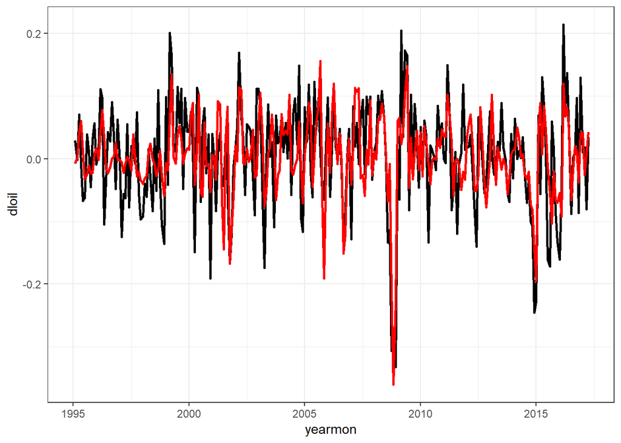

```r
g2<-ggplot() +
  geom_line(data = ss, aes(yearmon, dloil),colour="black",size=1) +
  geom_line(data = ss, aes(yearmon, dlgas), colour = 'red', size = 1)
g2
```

2. Perform unit root tests to verify that log pGASt and log pOILt are I(1).

```r
energy.ts1 <-
    energy_tbl%>%
    dplyr::select(yearmon, logpgas,logpoil) %>%
    drop_na() %>%
    tk_ts(select = c("logpoil", "logpgas"),start = .$yearmon[1],frequency = 12)
energy.ts2 <-
    energy_tbl%>%
    dplyr::select(yearmon, dloil, dlgas) %>%
    drop_na() %>%
    tk_ts(select = c("dloil","dlgas"),start = .$yearmon[1],frequency = 12)
##unit root test for the log term
 tk_ts(energy.ts1, select= c("logpoil", "logpgas")) %>%
   ur.ers(type="DF-GLS", model="trend") %>% summary()
```

```
##
## ###############################################
## # Elliot, Rothenberg and Stock Unit Root Test #
## ###############################################
##
## Test of type DF-GLS
## detrending of series with intercept and trend
##
##
## Call:
## lm(formula = dfgls.form, data = data.dfgls)
##
## Residuals:
##     Min      1Q  Median      3Q     Max
## -3.9688 -0.0330  0.0110  0.0557  0.2284
##
## Coefficients:
##               Estimate Std. Error t value Pr(>|t|)
## yd.lag       -0.009808   0.006044  -1.623    0.105
## yd.diff.lag1  0.051225   0.042938   1.193    0.233
## yd.diff.lag2 -0.007461   0.042975  -0.174    0.862
## yd.diff.lag3 -0.016140   0.042974  -0.376    0.707
## yd.diff.lag4 -0.022410   0.042956  -0.522    0.602
##
## Residual standard error: 0.1864 on 542 degrees of freedom
## Multiple R-squared:  0.00841,    Adjusted R-squared:  -0.0007379
## F-statistic: 0.9193 on 5 and 542 DF,  p-value: 0.4679
##
##
## Value of test-statistic is: -1.6226
##
## Critical values of DF-GLS are:
##                  1pct  5pct 10pct
## critical values -3.48 -2.89 -2.57
```

```r
## unit root test for the first difference
 tk_ts(energy.ts2,select= c("dloil", "dlgas")) %>%
   ur.ers(type="DF-GLS", model="trend") %>% summary()
```

```
##
## ###############################################
## # Elliot, Rothenberg and Stock Unit Root Test #
## ###############################################
##
## Test of type DF-GLS
## detrending of series with intercept and trend
##
##
## Call:
## lm(formula = dfgls.form, data = data.dfgls)
##
## Residuals:
##       Min        1Q    Median        3Q       Max
## -0.286903 -0.038346  0.000435  0.042647  0.214240
##
## Coefficients:
##              Estimate Std. Error t value Pr(>|t|)
## yd.lag       -0.76650    0.07340 -10.443   <2e-16 ***
## yd.diff.lag1  0.09741    0.06713   1.451    0.147
## yd.diff.lag2  0.07760    0.05950   1.304    0.193
## yd.diff.lag3  0.03692    0.05176   0.713    0.476
## yd.diff.lag4  0.03580    0.04309   0.831    0.406
## ---
## Signif. codes:  0 '***' 0.001 '**' 0.01 '*' 0.05 '.' 0.1 ' ' 1
##
## Residual standard error: 0.07145 on 540 degrees of freedom
## Multiple R-squared:  0.3423, Adjusted R-squared:  0.3362
## F-statistic:  56.2 on 5 and 540 DF,  p-value: < 2.2e-16
##
##
## Value of test-statistic is: -10.4431
##
## Critical values of DF-GLS are:
##                  1pct  5pct 10pct
## critical values -3.48 -2.89 -2.57
```

Comments: 1)From the ERS unit root test of log term, we fail to reject the null hypothesis that there is unit root.  
2)From the ERS unit root test of the first difference, we have to reject the null hypothesis that there is unit root, namely there is no unit root but trend stationary.  
so we need to use the first difference data.

3. Determine the number of lags to include in cointegration analysis using Schwarz information criterion. Run the Johansen’s trace and maximum eigenvalue cointegration tests for (log pGAS , log pOIL ) using the sample 1995M1-2017M12. Use time series plots from (a) as a guide to determine the specification of the deterministic components in the cointegration test (i.e. whether to use Case 2, Case 3, of Case 4 cointegration test).

```r
# determine the number of lags
varp <- VAR(energy.ts1, ic = "SC", lag.max = 24, type = "const")
varp
```

```
##
## VAR Estimation Results:
## =======================
##
## Estimated coefficients for equation logpoil:
## ============================================
## Call:
## logpoil = logpoil.l1 + logpgas.l1 + logpoil.l2 + logpgas.l2 + logpoil.l3 + logpgas.l3 + const
##
##   logpoil.l1   logpgas.l1   logpoil.l2   logpgas.l2   logpoil.l3
##  1.285944284 -0.121686273 -0.205520325  0.115446880 -0.096626173
##   logpgas.l3        const
##  0.008586051  0.062704543
##
##
## Estimated coefficients for equation logpgas:
## ============================================
## Call:
## logpgas = logpoil.l1 + logpgas.l1 + logpoil.l2 + logpgas.l2 + logpoil.l3 + logpgas.l3 + const
##
##   logpoil.l1   logpgas.l1   logpoil.l2   logpgas.l2   logpoil.l3
##  0.321855096  1.094064320 -0.202983280 -0.434675358  0.001720196
##   logpgas.l3        const
##  0.151550896 -0.325859056
```

```r
summary(varp)
```

```
##
## VAR Estimation Results:
## =========================
## Endogenous variables: logpoil, logpgas
## Deterministic variables: const
## Sample size: 273
## Log Likelihood: 810.199
## Roots of the characteristic polynomial:
## 0.9786 0.7551 0.4813 0.4643 0.4643 0.1912
## Call:
## VAR(y = energy.ts1, type = "const", lag.max = 24, ic = "SC")
##
##
## Estimation results for equation logpoil:
## ========================================
## logpoil = logpoil.l1 + logpgas.l1 + logpoil.l2 + logpgas.l2 + logpoil.l3 + logpgas.l3 + const
##
##             Estimate Std. Error t value Pr(>|t|)
## logpoil.l1  1.285944   0.082431  15.600   <2e-16 ***
## logpgas.l1 -0.121686   0.129790  -0.938    0.349
## logpoil.l2 -0.205520   0.114995  -1.787    0.075 .
## logpgas.l2  0.115447   0.175501   0.658    0.511
## logpoil.l3 -0.096626   0.088412  -1.093    0.275
## logpgas.l3  0.008586   0.114627   0.075    0.940
## const       0.062705   0.144780   0.433    0.665
## ---
## Signif. codes:  0 '***' 0.001 '**' 0.01 '*' 0.05 '.' 0.1 ' ' 1
##
##
## Residual standard error: 0.08232 on 266 degrees of freedom
## Multiple R-Squared: 0.9829,  Adjusted R-squared: 0.9825
## F-statistic:  2544 on 6 and 266 DF,  p-value: < 2.2e-16
##
##
## Estimation results for equation logpgas:
## ========================================
## logpgas = logpoil.l1 + logpgas.l1 + logpoil.l2 + logpgas.l2 + logpoil.l3 + logpgas.l3 + const
##
##            Estimate Std. Error t value Pr(>|t|)
## logpoil.l1  0.32186    0.05189   6.202 2.12e-09 ***
```

[output cut: 10 more lines]

```
## Residual standard error: 0.05183 on 266 degrees of freedom
## Multiple R-Squared: 0.9852,  Adjusted R-squared: 0.9849
## F-statistic:  2955 on 6 and 266 DF,  p-value: < 2.2e-16
##
##
##
## Covariance matrix of residuals:
##          logpoil  logpgas
## logpoil 0.006777 0.002942
## logpgas 0.002942 0.002686
##
## Correlation matrix of residuals:
##         logpoil logpgas
## logpoil  1.0000  0.6896
## logpgas  0.6896  1.0000
```

```r
# Trace test and  Eigenvalue Test for Case4
  ## trace test
energy_CA1 <- ca.jo(energy.ts1, ecdet = "trend", type = "trace", K = 3, spec = "transitory", season = 12)
summary(energy_CA1 )
```

```
##
## ######################
## # Johansen-Procedure #
## ######################
##
## Test type: trace statistic , with linear trend in cointegration
##
## Eigenvalues (lambda):
## [1]  1.037680e-01  1.873353e-02 -1.699366e-19
##
## Values of teststatistic and critical values of test:
##
##           test 10pct  5pct  1pct
## r <= 1 |  5.16 10.49 12.25 16.26
## r = 0  | 35.07 22.76 25.32 30.45
##
## Eigenvectors, normalised to first column:
## (These are the cointegration relations)
##
##               logpoil.l1  logpgas.l1    trend.l1
## logpoil.l1  1.0000000000  1.00000000   1.0000000
## logpgas.l1 -1.6267117480  3.75026554 -10.7065612
## trend.l1    0.0009487176 -0.01919425   0.1692144
##
## Weights W:
## (This is the loading matrix)
##
##             logpoil.l1   logpgas.l1      trend.l1
## logpoil.d -0.006283109 -0.008367640 -2.545462e-19
## logpgas.d  0.138252677 -0.003301629  8.623684e-20
```

```r
  ##Eigenvalue Test
energy_CA2 <- ca.jo(energy.ts1, ecdet ="trend", type = "eigen",K = 3, spec = "transitory", season = 12)
summary(energy_CA2)
```

```
##
## ######################
## # Johansen-Procedure #
## ######################
##
## Test type: maximal eigenvalue statistic (lambda max) , with linear trend in cointegration
##
## Eigenvalues (lambda):
## [1]  1.037680e-01  1.873353e-02 -1.699366e-19
##
## Values of teststatistic and critical values of test:
##
##           test 10pct  5pct  1pct
## r <= 1 |  5.16 10.49 12.25 16.26
## r = 0  | 29.91 16.85 18.96 23.65
##
## Eigenvectors, normalised to first column:
## (These are the cointegration relations)
##
##               logpoil.l1  logpgas.l1    trend.l1
## logpoil.l1  1.0000000000  1.00000000   1.0000000
## logpgas.l1 -1.6267117480  3.75026554 -10.7065612
## trend.l1    0.0009487176 -0.01919425   0.1692144
##
## Weights W:
## (This is the loading matrix)
##
##             logpoil.l1   logpgas.l1      trend.l1
## logpoil.d -0.006283109 -0.008367640 -2.545462e-19
## logpgas.d  0.138252677 -0.003301629  8.623684e-20
```

```r
# test for "trend"
lttest(energy_CA2, r=1)
```

```
## LR-test for no linear trend
##
## H0: H*2(r<=1)
## H1: H2(r<=1)
##
## Test statistic is distributed as chi-square
## with 1 degress of freedom
##         test statistic p-value
## LR test           0.63    0.43
```

```r
# Trace test and  Eigenvalue Test for Case3
     ## trace test
energy_CA1 <- ca.jo(energy.ts1, ecdet = "none", type = "trace", K = 3, spec = "transitory", season = 12)
summary(energy_CA1 )
```

```
##
## ######################
## # Johansen-Procedure #
## ######################
##
## Test type: trace statistic , with linear trend
##
## Eigenvalues (lambda):
## [1] 0.08250709 0.01001621
##
## Values of teststatistic and critical values of test:
##
##           test 10pct  5pct  1pct
## r <= 1 |  2.75  6.50  8.18 11.65
## r = 0  | 26.26 15.66 17.95 23.52
##
## Eigenvectors, normalised to first column:
## (These are the cointegration relations)
##
##            logpoil.l1 logpgas.l1
## logpoil.l1   1.000000    1.00000
## logpgas.l1  -1.468733  -45.61324
##
## Weights W:
## (This is the loading matrix)
##
##            logpoil.l1   logpgas.l1
## logpoil.d -0.04947140 0.0004212726
## logpgas.d  0.09148091 0.0001988976
```

```r
  ##Eigenvalue Test
energy_CA2 <- ca.jo(energy.ts1, ecdet ="none", type = "eigen",K = 3, spec = "transitory", season = 12)
summary(energy_CA2)
```

```
##
## ######################
## # Johansen-Procedure #
## ######################
##
## Test type: maximal eigenvalue statistic (lambda max) , with linear trend
##
## Eigenvalues (lambda):
## [1] 0.08250709 0.01001621
##
## Values of teststatistic and critical values of test:
##
##           test 10pct  5pct  1pct
## r <= 1 |  2.75  6.50  8.18 11.65
## r = 0  | 23.51 12.91 14.90 19.19
##
## Eigenvectors, normalised to first column:
## (These are the cointegration relations)
##
##            logpoil.l1 logpgas.l1
## logpoil.l1   1.000000    1.00000
## logpgas.l1  -1.468733  -45.61324
##
## Weights W:
## (This is the loading matrix)
##
##            logpoil.l1   logpgas.l1
## logpoil.d -0.04947140 0.0004212726
## logpgas.d  0.09148091 0.0001988976
```

Comments: (1) According to Schwarz information criterion, we can select the number of lags as 3. (2) From the time series plots from (a), it looks like Case 4 because of the similar trend for both logpoil and logpgas. (3) The value of the trace test statistic 35.07 is greater than all the critical values for H0:r=0. Looking at the eigen test, the test statistic 29.91 is greater than the critical value for H0:r=0 at 5% significance level, while both test statistics are smaller than the critical value for H0:r<=1, so we reject r=0 but fail to reject r<=1, therefore r=1, it suggests that the data of Gas and Oil have one cointegrating relationship. (4) but from lltest, we fail to reject the null hypothesis that there is no linear trend, then reconsidering the time series plots from (a), then this is case 3: unrestricted constant (5) For Case3, we can still get r=1.

4. Perform the test for the presence of a restricted constant rather than unrestricted constant in the model.

```r
  ## trace test
energy_CA3 <- ca.jo(energy.ts1, ecdet = "const", type = "trace", K = 3, spec = "transitory", season = 12)
summary(energy_CA3 )
```

```
##
## ######################
## # Johansen-Procedure #
## ######################
##
## Test type: trace statistic , without linear trend and constant in cointegration
##
## Eigenvalues (lambda):
## [1] 8.278024e-02 1.229177e-02 2.008124e-18
##
## Values of teststatistic and critical values of test:
##
##           test 10pct  5pct  1pct
## r <= 1 |  3.38  7.52  9.24 12.97
## r = 0  | 26.97 17.85 19.96 24.60
##
## Eigenvectors, normalised to first column:
## (These are the cointegration relations)
##
##            logpoil.l1 logpgas.l1  constant
## logpoil.l1   1.000000   1.000000  1.000000
## logpgas.l1  -1.469517   6.073866 -3.123976
## constant    -2.777754  -9.416696 -3.100568
##
## Weights W:
## (This is the loading matrix)
##
##            logpoil.l1   logpgas.l1      constant
## logpoil.d -0.04657971 -0.002470419  5.896215e-17
## logpgas.d  0.09283424 -0.001154441 -1.209843e-16
```

```r
  ##Eigenvalue Test
energy_CA4 <- ca.jo(energy.ts1, ecdet ="const", type = "eigen",K = 3, spec = "transitory", season = 12)
summary(energy_CA4)
```

```
##
## ######################
## # Johansen-Procedure #
## ######################
##
## Test type: maximal eigenvalue statistic (lambda max) , without linear trend and constant in cointegration
##
## Eigenvalues (lambda):
## [1] 8.278024e-02 1.229177e-02 2.008124e-18
##
## Values of teststatistic and critical values of test:
##
##           test 10pct  5pct  1pct
## r <= 1 |  3.38  7.52  9.24 12.97
## r = 0  | 23.59 13.75 15.67 20.20
##
## Eigenvectors, normalised to first column:
## (These are the cointegration relations)
##
##            logpoil.l1 logpgas.l1  constant
## logpoil.l1   1.000000   1.000000  1.000000
## logpgas.l1  -1.469517   6.073866 -3.123976
## constant    -2.777754  -9.416696 -3.100568
##
## Weights W:
## (This is the loading matrix)
##
##            logpoil.l1   logpgas.l1      constant
## logpoil.d -0.04657971 -0.002470419  5.896215e-17
## logpgas.d  0.09283424 -0.001154441 -1.209843e-16
```

Comments: In the case2–restricted constant, the value of the trace test statistic 26.97 is greater than all the critical values for H0:r=0. Looking at the eigen test, the test statistic 23.59 is greater than all the critical values for H0:r=0, while both test statistics are smaller than the critical value for H0:r<=1, so we reject r=0 but fail to reject r<=1, therefore r=1, it suggests that the data of Gas and Oil have one cointegrating relationship.

5. Use the 1995M1-2017M12 sample to estimate a bivariate VEC model for (log pGAS , log pOIL ).

```r
energy_VEC <- cajorls(energy_CA4, r = 1)
energy_VEC
```

```
## $rlm
##
## Call:
## lm(formula = substitute(form1), data = data.mat)
##
## Coefficients:
##              logpoil.d   logpgas.d
## ect1         -0.0465797   0.0928342
## sd1           0.0416891   0.0393721
## sd2           0.0439070   0.0396088
## sd3           0.0833471   0.0832174
## sd4           0.0573362   0.0655020
## sd5           0.0446961   0.0672215
## sd6           0.0342788   0.0482058
## sd7           0.0372419   0.0301175
## sd8           0.0263954   0.0403221
## sd9           0.0338940   0.0385986
## sd10          0.0164143  -0.0004563
## sd11         -0.0070476   0.0009893
## logpoil.dl1   0.3737361   0.2629747
## logpgas.dl1  -0.3352471   0.0696406
## logpoil.dl2   0.1850929   0.0910178
## logpgas.dl2  -0.0752505  -0.2506345
##
##
## $beta
##                 ect1
## logpoil.l1  1.000000
## logpgas.l1 -1.469517
## constant   -2.777754
```

Comments: From the above result, we can get that when include a constant in the cointegrating relationship, conintegrating vecor is estimated as beta=(1, -1.469517, -2.777754)‘, adjustment parameters are estimated as Alpha=( -0.0465797, 0.0928342)’.

6. Are the adjustment parameters Alpha1 and Alpha2 in the estimated VEC model statistically significant? Are their signs consistent with error correction mechanism that moves the system back to the long run equilibrium, whenever there is a disruption and z(t???1) is not equal to 0?

```r
summary(energy_VEC$rlm)
```

```
## Response logpoil.d :
##
## Call:
## lm(formula = logpoil.d ~ ect1 + sd1 + sd2 + sd3 + sd4 + sd5 +
##     sd6 + sd7 + sd8 + sd9 + sd10 + sd11 + logpoil.dl1 + logpgas.dl1 +
##     logpoil.dl2 + logpgas.dl2 - 1, data = data.mat)
##
## Residuals:
##       Min        1Q    Median        3Q       Max
## -0.260511 -0.045153  0.006797  0.060345  0.200887
##
## Coefficients:
##              Estimate Std. Error t value Pr(>|t|)
## ect1        -0.046580   0.055637  -0.837  0.40326
## sd1          0.041689   0.024477   1.703  0.08974 .
## sd2          0.043907   0.025092   1.750  0.08134 .
## sd3          0.083347   0.025300   3.294  0.00113 **
## sd4          0.057336   0.026078   2.199  0.02880 *
## sd5          0.044696   0.026230   1.704  0.08959 .
## sd6          0.034279   0.026125   1.312  0.19065
## sd7          0.037242   0.025501   1.460  0.14540
## sd8          0.026395   0.024774   1.065  0.28766
## sd9          0.033894   0.024598   1.378  0.16942
## sd10         0.016414   0.024842   0.661  0.50937
## sd11        -0.007048   0.024488  -0.288  0.77373
## logpoil.dl1  0.373736   0.089405   4.180    4e-05 ***
## logpgas.dl1 -0.335247   0.140029  -2.394  0.01738 *
## logpoil.dl2  0.185093   0.092017   2.012  0.04532 *
## logpgas.dl2 -0.075250   0.121656  -0.619  0.53676
## ---
## Signif. codes:  0 '***' 0.001 '**' 0.01 '*' 0.05 '.' 0.1 ' ' 1
##
## Residual standard error: 0.08142 on 257 degrees of freedom
## Multiple R-squared:  0.1373, Adjusted R-squared:  0.0836
## F-statistic: 2.556 on 16 and 257 DF,  p-value: 0.001097
##
##
## Response logpgas.d :
##
## Call:
```

[output cut: 17 more lines]

```
## sd7          0.0301175  0.0146894   2.050 0.041351 *
## sd8          0.0403221  0.0142702   2.826 0.005090 **
## sd9          0.0385986  0.0141688   2.724 0.006888 **
## sd10        -0.0004563  0.0143099  -0.032 0.974588
## sd11         0.0009893  0.0141057   0.070 0.944143
## logpoil.dl1  0.2629747  0.0514997   5.106 6.40e-07 ***
## logpgas.dl1  0.0696406  0.0806603   0.863 0.388733
## logpoil.dl2  0.0910178  0.0530042   1.717 0.087151 .
## logpgas.dl2 -0.2506345  0.0700771  -3.577 0.000416 ***
## ---
## Signif. codes:  0 '***' 0.001 '**' 0.01 '*' 0.05 '.' 0.1 ' ' 1
##
## Residual standard error: 0.0469 on 257 degrees of freedom
## Multiple R-squared:  0.476,  Adjusted R-squared:  0.4434
## F-statistic: 14.59 on 16 and 257 DF,  p-value: < 2.2e-16
```

7. Test the restriction alpha2 = 0 using the likelihood ratio test.

```r
rest_alpha <- matrix(c(1,0), c(2,1))
energy_ca_ralpha <- alrtest(energy_CA4, A = rest_alpha, r = 1)
summary(energy_ca_ralpha)
```

```
##
## ######################
## # Johansen-Procedure #
## ######################
##
## Estimation and testing under linear restrictions on beta
##
## The VECM has been estimated subject to:
## beta=H*phi and/or alpha=A*psi
##
##      [,1]
## [1,]    1
## [2,]    0
##
## Eigenvalues of restricted VAR (lambda):
## [1] 0.0571 0.0000 0.0000
##
## The value of the likelihood ratio test statistic:
## 7.54 distributed as chi square with 1 df.
## The p-value of the test statistic is: 0.01
##
## Eigenvectors, normalised to first column
## of the restricted VAR:
##
##                  [,1]
## RK.logpoil.l1  1.0000
## RK.logpgas.l1 -1.4161
## RK.constant   -2.8248
##
## Weights W of the restricted VAR:
##
##         [,1]
## [1,] -0.1569
## [2,]  0.0000
```

8. What is the intuition for imposing the restriction in (f), what does it imply for the response of log pGAS and log pOIL to a disruption such that z(t???1) < 0?

Comments: Since alpha1<0 and ahpha2>0, then when z(t???1) < 0, logpgas would decrease and logpoil would increase, the error correction mechanism could move the system back to the long run equilibrium.